# Mini Data Analysis Milestone 2

*To complete this milestone, you can either edit [this `.rmd` file](https://raw.githubusercontent.com/UBC-STAT/stat545.stat.ubc.ca/master/content/mini-project/mini-project-2.Rmd) directly. Fill in the sections that are commented out with `<!--- start your work here--->`. When you are done, make sure to knit to an `.md` file by changing the output in the YAML header to `github_document`, before submitting a tagged release on canvas.*

# Welcome back to your mini data analysis project!

This time, we will explore more in depth the concept of *tidy data*, and hopefully investigate further into your research questions that you defined in milestone 1.

**NOTE**: The main purpose of the mini data analysis is to integrate what you learn in class in an analysis. Although each milestone provides a framework for you to conduct your analysis, it’s possible that you might find the instructions too rigid for your data set. If this is the case, you may deviate from the instructions – just make sure you’re demonstrating a wide range of tools and techniques taught in this class.

Begin by loading your data and the tidyverse package below:

```r
library(datateachr) # <- might contain the data you picked!
library(tidyverse)
```

```r
library(ggplot2)
library(forcats)
library(plyr)
library(dplyr)
```

# Learning Objectives

By the end of this milestone, you should:

- Become familiar with manipulating and summarizing your data in tibbles using `dplyr` and `tidyr`, with a research question in mind.
- Understand what *tidy* data is, and how to create it. In milestone 3, we will explore when this might be useful.
- Generate a reproducible and clear report using R Markdown.
- Gain a greater understanding of how to use R to answer research questions about your data.

**Things to keep in mind**

- Remember to document your code, be explicit about what you are doing, and write notes in this markdown document when you feel that context is required. Create your analysis as if someone else will be reading it! **There will be 2.5 points reserved for reproducibility, readability, and repo organization.**
- Before working on each task, you should always keep in mind the specific **research question** that you’re trying to answer.

# Task 1: Process and summarize your data (15 points)

From milestone 1, you should have an idea of the basic structure of your dataset (e.g. number of rows and columns, class types, etc.). Here, we will start investigating your data more in-depth using various data manipulation functions.

### 1.1 (2.5 points)

First, write out the 4 research questions you defined in milestone 1 were. This will guide your work through milestone 2:

```r
# Summary of *apt_buildings* data set for reference:

str(apt_buildings)
```

```
## tibble [3,455 × 37] (S3: tbl_df/tbl/data.frame)
##  $ id                              : num [1:3455] 10359 10360 10361 10362 10363 ...
##  $ air_conditioning                : chr [1:3455] "NONE" "NONE" "NONE" "NONE" ...
##  $ amenities                       : chr [1:3455] "Outdoor rec facilities" "Outdoor pool" NA NA ...
##  $ balconies                       : chr [1:3455] "YES" "YES" "YES" "YES" ...
##  $ barrier_free_accessibilty_entr  : chr [1:3455] "YES" "NO" "NO" "YES" ...
##  $ bike_parking                    : chr [1:3455] "0 indoor parking spots and 10 outdoor parking spots" "0 indoor parking spots and 34 outdoor parking spots" "Not Available" "Not Available" ...
##  $ exterior_fire_escape            : chr [1:3455] "NO" "NO" "NO" "YES" ...
##  $ fire_alarm                      : chr [1:3455] "YES" "YES" "YES" "YES" ...
##  $ garbage_chutes                  : chr [1:3455] "YES" "YES" "NO" "NO" ...
##  $ heating_type                    : chr [1:3455] "HOT WATER" "HOT WATER" "HOT WATER" "HOT WATER" ...
##  $ intercom                        : chr [1:3455] "YES" "YES" "YES" "YES" ...
##  $ laundry_room                    : chr [1:3455] "YES" "YES" "YES" "YES" ...
##  $ locker_or_storage_room          : chr [1:3455] "NO" "YES" "YES" "YES" ...
##  $ no_of_elevators                 : num [1:3455] 3 3 0 1 0 0 0 2 4 2 ...
```

[output cut: 23 more lines]

#### 1.1.1. Research question 1: Investigating the relationship between building age and building height

Investigate the relationship between building age and building height. One could hypothesize that newer buildings might tend to be taller as construction technology has improved and urban density has increased.

#### 1.1.2. Research question 2: Investigating the relationship between building height, number of units, and balconies

Investigate the relationship between building height, number of units, and balconies. One could hypothesize that, given constant area per floor and area per unit, building height and number of units would display a positive correlation. Similarly, one could hypothesize that higher buildings or buildings with more units are more likely to have balconies.

#### 1.1.3. Research question 3: Investigating building age dependency of air conditioning type

Investigate the relationship between building age and air conditioning type. For example, one could hypothesize that newer buildings might more frequently have central air conditioning, while older buildings might more frequently lack air conditioning.

#### 1.1.4. Research question 4: Investigating the relationship between building height and ward

Investigate the relationship between building height and city ward. One could hypothesize that buildings in denser downtown wards might tend to be higher, while buildings in outlying suburban wards might tend to be shorter.

### 1.2 (10 points)

Now, for each of your four research questions, choose one task from options 1-4 (summarizing), and one other task from 4-8 (graphing). You should have 2 tasks done for each research question (8 total). Make sure it makes sense to do them! (e.g. don’t use a numerical variables for a task that needs a categorical variable.). Comment on why each task helps (or doesn’t!) answer the corresponding research question.

Ensure that the output of each operation is printed!

**Summarizing:**

1. Compute the *range*, *mean*, and *two other summary statistics* of **one numerical variable** across the groups of **one categorical variable** from your data.
2. Compute the number of observations for at least one of your categorical variables. Do not use the function `table()`!
3. Create a categorical variable with 3 or more groups from an existing numerical variable. You can use this new variable in the other tasks! *An example: age in years into “child, teen, adult, senior”.*
4. Based on two categorical variables, calculate two summary statistics of your choosing.

**Graphing:**

5. Create a graph out of summarized variables that has at least two geom layers.
6. Create a graph of your choosing, make one of the axes logarithmic, and format the axes labels so that they are “pretty” or easier to read.
7. Make a graph where it makes sense to customize the alpha transparency.
8. Create 3 histograms out of summarized variables, with each histogram having different sized bins. Pick the “best” one and explain why it is the best

Make sure it’s clear what research question you are doing each operation for!

#### 1.2.1. Research question 1: Investigating the relationship between building age and number of storeys

This question will be investigated using options 3 and 5.

```r
# Use mutate function to assign age category to a new column named *age_cat*
# *case_when* determines the age range based on the value of *year_built*

apt_buildings_age_cat <- apt_buildings %>%
  mutate(age_cat = case_when(year_built < 1900 ~ "1899 & before",
                             year_built < 1925 ~ "1900-1924",
                             year_built < 1950 ~ "1925-1950",
                             year_built < 2000 ~ "1950-1999",
                                TRUE ~ "2000 & later"))

head(apt_buildings_age_cat)
```

```
## # A tibble: 6 × 38
##      id air_conditioning amenities   balconies barrier_free_acc… bike_parking
##   <dbl> <chr>            <chr>       <chr>     <chr>             <chr>
## 1 10359 NONE             Outdoor re… YES       YES               0 indoor parki…
## 2 10360 NONE             Outdoor po… YES       NO                0 indoor parki…
## 3 10361 NONE             <NA>        YES       NO                Not Available
## 4 10362 NONE             <NA>        YES       YES               Not Available
## 5 10363 NONE             <NA>        NO        NO                12 indoor park…
## 6 10364 NONE             <NA>        NO        NO                Not Available
## # … with 32 more variables: exterior_fire_escape <chr>, fire_alarm <chr>,
## #   garbage_chutes <chr>, heating_type <chr>, intercom <chr>,
## #   laundry_room <chr>, locker_or_storage_room <chr>, no_of_elevators <dbl>,
## #   parking_type <chr>, pets_allowed <chr>, prop_management_company_name <chr>,
## #   property_type <chr>, rsn <dbl>, separate_gas_meters <chr>,
## #   separate_hydro_meters <chr>, separate_water_meters <chr>,
## #   site_address <chr>, sprinkler_system <chr>, visitor_parking <chr>, …
```

For option 5 (creating a graph of the summarized variables with 2+ geom layers), a box plot will be created for number of storeys in each age category.

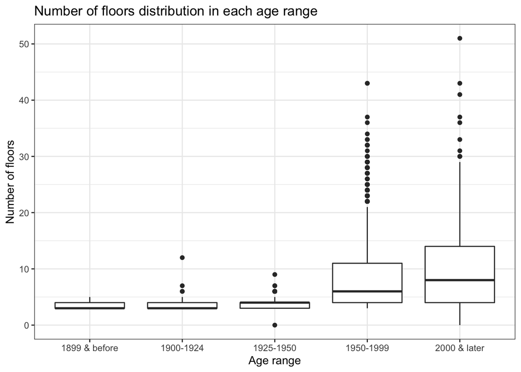

```r
# Use standard ggplot syntax to display the number of storeys (y axis) of each
# age category (x axis) in boxplot format.
# Specify x and y axis labels and a title, and select *theme_bw* as the colour palette

apt_buildings_age_cat %>%
  ggplot() + geom_boxplot(aes(x = age_cat, y = no_of_storeys)) +
    labs(y = "Number of floors", x = "Age range") +
    ggtitle("Number of floors distribution in each age range") +
    theme_bw()
```

This plot shows that there is a general increase in number of floors over time. However, there is little change in median number of floors until 1950. After 1950, the median number of floors increases somewhat. However, despite the moderate increase in mean after 1950, the most dramatic difference is the appearance of numerous outliers with as many as 40-50 floors. We might attribute this change to postwar changes in zoning rules and construction technology.

#### 1.2.2. Research question 2: Investigating the relationship between number of storeys, number of units, and balconies

This question will be investigated using options 1 and 7.

```r
# The data set is grouped by the categories of the balconies column
# The summarise function is then used to calculate the mean of each group

(apt_buildings %>%
  group_by(balconies) %>%
  summarise(no_of_units_mean = mean(no_of_units)))
```

```
##   no_of_units_mean
## 1         91.09117
```

```r
# The data set is grouped by the categories of the balconies column
# The summarise function is then used to calculate the rage of each group

(apt_buildings %>%
  group_by(balconies) %>%
  summarise(no_of_units_range = range(no_of_units)))
```

```
##   no_of_units_range
## 1                 0
## 2              4111
```

```r
# The data set is grouped by the categories of the balconies column
# The summarise function is then used to calculate the median of each group

(apt_buildings %>%
  group_by(balconies) %>%
  summarise(no_of_units_median = median(no_of_units)))
```

```
##   no_of_units_median
## 1                 52
```

```r
# The data set is grouped by the categories of the balconies column
# The summarise function is then used to calculate the standard deviation of each group

(apt_buildings %>%
  group_by(balconies) %>%
  summarise(no_of_units_sd = sd(no_of_units)))
```

```
##   no_of_units_sd
## 1        117.102
```

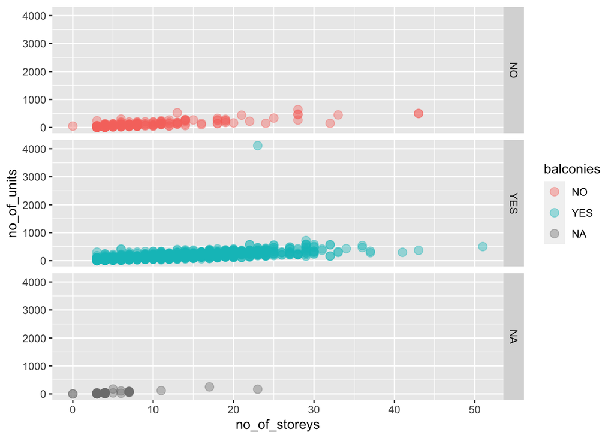

```r
#(apt_buildings_scatter_plot <- ggplot(apt_buildings) +
#    geom_point(aes(no_of_storeys, no_of_units), alpha = 0.2))

(apt_buildings_scatter_plot <- ggplot(apt_buildings, aes(no_of_storeys, no_of_units)) +
  geom_point(aes(color = balconies),
            size = 3,
            alpha = 0.4)) + facet_grid(balconies ~ .)
```

This plot repeats the result from milestone 1 that number of units and number of storeys are positively correlated. In terms of balconies, it seems that buildings with balconies are somewhat more distributed in the higher range of units/floors than those without.

#### 1.2.3. Research question 3: Investigating building age dependency of air conditioning type

This question will be investigated using options 1 and 5.

```r
# The data set is grouped by the categories of the air conditioning column
# The summarise function is then used to calculate the mean of each group

(apt_buildings %>%
  group_by(air_conditioning) %>%
  summarise(year_built_mean = mean(year_built)))
```

```
##   year_built_mean
## 1              NA
```

```r
# The data set is grouped by the categories of the air conditioning column
# The summarise function is then used to calculate the range of each group

(apt_buildings %>%
  group_by(air_conditioning) %>%
  summarise(year_built_range = range(year_built)))
```

```
##   year_built_range
## 1               NA
## 2               NA
```

```r
# The data set is grouped by the categories of the air conditioning column
# The summarise function is then used to calculate the median of each group

(apt_buildings %>%
  group_by(air_conditioning) %>%
  summarise(year_built_median = median(year_built)))
```

```
##   year_built_median
## 1                NA
```

```r
# The data set is grouped by the categories of the air conditioning column
# The summarise function is then used to calculate the standard deviation of each group

(apt_buildings %>%
  group_by(air_conditioning) %>%
  summarise(year_built_sd = sd(year_built)))
```

```
##   year_built_sd
## 1            NA
```

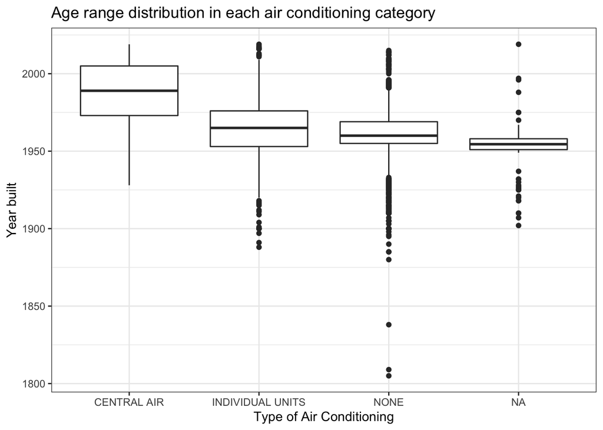

```r
# Use standard ggplot syntax to display the number of storeys (y axis) of each
# age category (x axis) in boxplot format.
# Specify x and y axis labels and a title, and select *theme_bw* as the colour palette


apt_buildings_age_cat %>%
  ggplot() + geom_boxplot(aes(x = air_conditioning, y = year_built)) +
    labs(y = "Year built", x = "Type of Air Conditioning") +
    ggtitle("Age range distribution in each air conditioning category") +
    theme_bw()
```

This plot further demonstrates the trend that central air is more common in newer buildings, and very rare in buildings before 1950. Buildings with individual units have a slightly newer median construction year than those with no air conditioning. However, there are many more recent outliers in the *individual units* and *none* categories, showing that buildings with these air conditioning types are still being built.

#### 1.2.4. Research question 4: Investigating the relationship between building height and ward

This question will be investigated using options 2 and 6.

For option 2 (calculate number of observations for one categorical variable), the number of buildings in each ward will be computed.

```r
# The count function is used to calculate the number of entries in each ward category.

count(apt_buildings, 'ward')
```

```
##    ward freq
## 1    01   81
## 2    02  130
## 3    03  240
## 4    04  198
## 5    05  233
## 6    06  236
## 7    07  102
## 8    08  242
## 9    09   89
## 10   10   47
## 11   11  132
## 12   12  331
## 13   13  208
## 14   14  131
## 15   15  168
## 16   16  155
## 17   17   62
## 18   18   46
## 19   19  173
## 20   20  159
## 21   21  135
## 22   22   42
## 23   23    8
## 24   24   78
## 25   25   28
## 26   YY    1
```

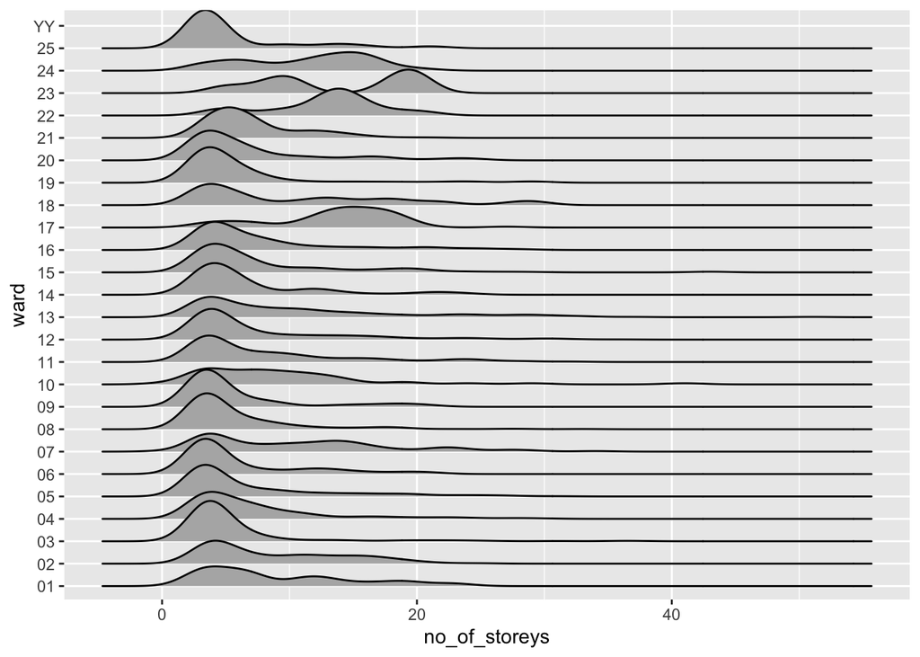

```r
# ggplot is used to create a plot with number of stories and ward as the x and y variables respectively
# the ggridges package is loaded and the geom_density_ridges function is used to create the ridge plot

apt_buildings %>%
   ggplot(aes(no_of_storeys, ward)) +
   ggridges::geom_density_ridges()
```

### 1.3 (2.5 points)

Based on the operations that you’ve completed, how much closer are you to answering your research questions? Think about what aspects of your research questions remain unclear. Can your research questions be refined, now that you’ve investigated your data a bit more? Which research questions are yielding interesting results?

These results provide useful answers to the four research questions addressed in this analysis. However, more detailed investigates of all four relationships are still possible. Research questions 3 and 4 are yielding particularly interesting results, with various questions left to investigate further.

# Task 2: Tidy your data (12.5 points)

In this task, we will do several exercises to reshape our data. The goal here is to understand how to do this reshaping with the `tidyr` package.

A reminder of the definition of *tidy* data:

- Each row is an **observation**
- Each column is a **variable**
- Each cell is a **value**

*Tidy’ing* data is sometimes necessary because it can simplify computation. Other times it can be nice to organize data so that it can be easier to understand when read manually.

### 2.1 (2.5 points)

Based on the definition above, can you identify if your data is tidy or untidy? Go through all your columns, or if you have >8 variables, just pick 8, and explain whether the data is untidy or tidy.

The data is currently in tidy form, because each row represents one observation (i.e. one apartment building). For that reason, it would not be reasonably possible to further reduce the number of rows.

### 2.2 (5 points)

Now, if your data is tidy, untidy it! Then, tidy it back to it’s original state.

If your data is untidy, then tidy it! Then, untidy it back to it’s original state.

Be sure to explain your reasoning for this task. Show us the “before” and “after”.

```r
# To simplify, select only 8 columns of the table.

selected_apt_buildings <- select(apt_buildings, id, separate_gas_meters, separate_hydro_meters, separate_water_meters, no_of_units, ward, air_conditioning, heating_type)

head(selected_apt_buildings)
```

```
## # A tibble: 6 × 8
##      id separate_gas_met… separate_hydro_me… separate_water_m… no_of_units ward
##   <dbl> <chr>             <chr>              <chr>                   <dbl> <chr>
## 1 10359 NO                YES                NO                        218 17
## 2 10360 NO                YES                NO                        206 17
## 3 10361 NO                YES                NO                         34 03
## 4 10362 NO                YES                NO                         42 03
## 5 10363 NO                YES                NO                         25 02
## 6 10364 NO                YES                NO                         34 02
## # … with 2 more variables: air_conditioning <chr>, heating_type <chr>
```

```r
# Because the data is already tidy, choose to untidy by adding separate rows for each apartment building's separate utility meters

(untidy <- selected_apt_buildings %>%
  pivot_longer(cols = c(separate_gas_meters, separate_hydro_meters, separate_water_meters),
               names_to  = "utility_meter",
               values_to = "utility_meter_separate"))
```

```
## # A tibble: 10,365 × 7
##       id no_of_units ward  air_conditioning heating_type utility_meter
##    <dbl>       <dbl> <chr> <chr>            <chr>        <chr>
##  1 10359         218 17    NONE             HOT WATER    separate_gas_meters
##  2 10359         218 17    NONE             HOT WATER    separate_hydro_meters
##  3 10359         218 17    NONE             HOT WATER    separate_water_meters
##  4 10360         206 17    NONE             HOT WATER    separate_gas_meters
##  5 10360         206 17    NONE             HOT WATER    separate_hydro_meters
##  6 10360         206 17    NONE             HOT WATER    separate_water_meters
##  7 10361          34 03    NONE             HOT WATER    separate_gas_meters
##  8 10361          34 03    NONE             HOT WATER    separate_hydro_meters
##  9 10361          34 03    NONE             HOT WATER    separate_water_meters
## 10 10362          42 03    NONE             HOT WATER    separate_gas_meters
## # … with 10,355 more rows, and 1 more variable: utility_meter_separate <chr>
```

```r
head(untidy)
```

```
## # A tibble: 6 × 7
##      id no_of_units ward  air_conditioning heating_type utility_meter
##   <dbl>       <dbl> <chr> <chr>            <chr>        <chr>
## 1 10359         218 17    NONE             HOT WATER    separate_gas_meters
## 2 10359         218 17    NONE             HOT WATER    separate_hydro_meters
## 3 10359         218 17    NONE             HOT WATER    separate_water_meters
## 4 10360         206 17    NONE             HOT WATER    separate_gas_meters
## 5 10360         206 17    NONE             HOT WATER    separate_hydro_meters
## 6 10360         206 17    NONE             HOT WATER    separate_water_meters
## # … with 1 more variable: utility_meter_separate <chr>
```

```r
# Re-tidy by converting back to one type of utility meter per column

re_tidy <- untidy %>%
    pivot_wider(id_cols = c(-utility_meter, -utility_meter_separate),
                names_from = utility_meter,
                values_from = utility_meter_separate)

head(re_tidy)
```

```
## # A tibble: 6 × 8
##      id no_of_units ward  air_conditioning heating_type separate_gas_meters
##   <dbl>       <dbl> <chr> <chr>            <chr>        <chr>
## 1 10359         218 17    NONE             HOT WATER    NO
## 2 10360         206 17    NONE             HOT WATER    NO
## 3 10361          34 03    NONE             HOT WATER    NO
## 4 10362          42 03    NONE             HOT WATER    NO
## 5 10363          25 02    NONE             HOT WATER    NO
## 6 10364          34 02    NONE             HOT WATER    NO
## # … with 2 more variables: separate_hydro_meters <chr>,
## #   separate_water_meters <chr>
```

### 2.3 (5 points)

Now, you should be more familiar with your data, and also have made progress in answering your research questions. Based on your interest, and your analyses, pick 2 of the 4 research questions to continue your analysis in milestone 3, and explain your decision.

Try to choose a version of your data that you think will be appropriate to answer these 2 questions in milestone 3. Use between 4 and 8 functions that we’ve covered so far (i.e. by filtering, cleaning, tidy’ing, dropping irrelvant columns, etc.).

Research questions 3 and 4 are yielding particularly interesting results, and there are still various questions left to investigate further. Therefore, these two questions will be investigated further in milestone 3.

The data is already correctly tidy’ed for the purpose of these questions.

To make a suitable data set for the questions, it is possible to drop all irrelevant columns.

```r
apt_buildings_dropped <- select(apt_buildings, id, air_conditioning, ward, year_built, no_of_storeys, site_address, no_of_elevators, no_of_units)

head(apt_buildings_dropped)
```

```
## # A tibble: 6 × 8
##      id air_conditioning ward  year_built no_of_storeys site_address
##   <dbl> <chr>            <chr>      <dbl>         <dbl> <chr>
## 1 10359 NONE             17          1967            17 65  FOREST MANOR RD
## 2 10360 NONE             17          1970            14 70  CLIPPER RD
## 3 10361 NONE             03          1927             4 2651  BLOOR ST W
## 4 10362 NONE             03          1959             5 22  BURNHAMTHORPE RD
## 5 10363 NONE             02          1943             4 18  ANGLESEY BLVD
## 6 10364 NONE             02          1952             4 308  THE KINGSWAY
## # … with 2 more variables: no_of_elevators <dbl>, no_of_units <dbl>
```

We can also create two separate data sets where the “YY” entries are dropped for *ward* and “NA” entries dropped for *air_conditioning*.

```r
apt_buildings_no_YY <- filter(apt_buildings_dropped, ward != "YY")

head(apt_buildings_no_YY)
```

```
## # A tibble: 6 × 8
##      id air_conditioning ward  year_built no_of_storeys site_address
##   <dbl> <chr>            <chr>      <dbl>         <dbl> <chr>
## 1 10359 NONE             17          1967            17 65  FOREST MANOR RD
## 2 10360 NONE             17          1970            14 70  CLIPPER RD
## 3 10361 NONE             03          1927             4 2651  BLOOR ST W
## 4 10362 NONE             03          1959             5 22  BURNHAMTHORPE RD
## 5 10363 NONE             02          1943             4 18  ANGLESEY BLVD
## 6 10364 NONE             02          1952             4 308  THE KINGSWAY
## # … with 2 more variables: no_of_elevators <dbl>, no_of_units <dbl>
```

```r
apt_buildings_no_NA <- filter(apt_buildings_dropped, air_conditioning != "NA")

head(apt_buildings_no_NA)
```

```
## # A tibble: 6 × 8
##      id air_conditioning ward  year_built no_of_storeys site_address
##   <dbl> <chr>            <chr>      <dbl>         <dbl> <chr>
## 1 10359 NONE             17          1967            17 65  FOREST MANOR RD
## 2 10360 NONE             17          1970            14 70  CLIPPER RD
## 3 10361 NONE             03          1927             4 2651  BLOOR ST W
## 4 10362 NONE             03          1959             5 22  BURNHAMTHORPE RD
## 5 10363 NONE             02          1943             4 18  ANGLESEY BLVD
## 6 10364 NONE             02          1952             4 308  THE KINGSWAY
## # … with 2 more variables: no_of_elevators <dbl>, no_of_units <dbl>
```

*When you are done, knit an `md` file. This is what we will mark! Make sure to open it and check that everything has knitted correctly before submitting your tagged release.*

### Attribution

Thanks to Victor Yuan for mostly putting this together.